# CA3: Naive Bayes Classifier

## Amir Ali Vahidi 810199511

#### Import needed libraries for further uses

```python
from __future__ import unicode_literals
import pandas as pd
import hazm
import matplotlib.pyplot as plt
from wordcloud import WordCloud
import os
from operator import itemgetter
import numpy as np
from arabic_reshaper import reshape
from colorama import Fore ,Back ,Style

normalizer = hazm.Normalizer()
tokenizer = hazm.WordTokenizer()
stemmer = hazm.Stemmer()
lemmatizer = hazm.Lemmatizer()
stop_words = set(hazm.stopwords_list())
```

### Faze 1: DATA PRE-PROCESS

#### Normalize Procces

##### I use 5 methods to increase accuracy of the model(**Q1 explained here**):

- `Normalize:` by normalizing data,it corrects spaces & semi spaces & apply some other correction to the data.
- `Tokenize:` it breaks senteces to words and return a list of words
- `*Stemmer:` This option seems to be removing semi-spaces(Nim faseleh). Since it corrupts some words and not work as expected, I don't use it in the proccesing part!
- `Lemmitize:` It turns verbs to their 'Bon-e-Maazi' and 'Bon-e-Mozare' format in Farsi. Two verbs having the same Bon mostly have the same concept in a sentence so they can be used instead of each other.
- `Remove Stop-words:` By removing most used words that are mostly in all kinds of textes, we decrease unnecessary words count for cheking the data. some of stop-words are like "آنها-است-سلام-من-آسان و..."
- `Remove Punctuation-marks:` Since puctuations can't be use for analysing the data here, we remove them from the data-set.

```python
def Normalizer(file_name):
    data_frame = pd.read_csv(file_name)

    def normalize_data_content(content): return normalizer.normalize(content) # normalize contents (correct nim-fasele & spaces & etc)

    def tokenizer_data_content(content): return tokenizer.tokenize(content)
    def stemmer_data_content(content): return [stemmer.stem(word) for word in content]
    def remove_stop_words(content): return [word for word in content if word not in stop_words]
    def lemmatizer_data_content(content): return [lemmatizer.lemmatize(word).split('#' , 1)[0] for word in content]

    punctuation_marks={"." , "،" , "؛" , "«" , "»" , "(" , ")" , "-" , "_", ":" , "!" , '"' , '؟' , '?'}
    def remove_punctuation_marks(content): return [word for word in content if word not in punctuation_marks]

    data_frame['content']=data_frame['content'].apply(normalize_data_content)

    data_frame['content']=data_frame['content'].apply(tokenizer_data_content)
    #data_frame['content']=data_frame['content'].apply(stemmer_data_content) # seems not to work as wanted and corrupt some words
    data_frame['content']=data_frame['content'].apply(remove_stop_words)
    data_frame['content']=data_frame['content'].apply(lemmatizer_data_content)
    data_frame['content']=data_frame['content'].apply(remove_punctuation_marks)
    data_frame['content']=data_frame['content'].apply(remove_stop_words)
    return data_frame
```

#### Reading train file and passing it to normalize function

```python
train_data_frame = Normalizer('train.csv')
```

### Faze 2: PROBLEM PROCESS

In this part, we calculate words count for all subjects

```python
subjects={'فناوری': dict(),'سلامت':dict(),'سیاسی':dict(),'ورزشی': dict(),'حوادث': dict(),'فرهنگی/هنری':dict()}

for index,data in train_data_frame.iterrows():
    for word in data.content:
        subjects[data.label][word]=subjects[data.label].get(word,0)+1

#print(subjects['فناوری'])
train_fanavari_number_of_unique_words=len(list(subjects['فناوری'].keys()))
train_havades_number_of_unique_words=len(list(subjects['حوادث'].keys()))
train_siasi_number_of_unique_words=len(list(subjects['سیاسی'].keys()))
train_varzeshi_number_of_unique_words=len(list(subjects['ورزشی'].keys()))
train_salamat_number_of_unique_words=len(list(subjects['سلامت'].keys()))
train_farhangi_number_of_unique_words=len(list(subjects['فرهنگی/هنری'].keys()))

train_fanavari_total_number_of_words=sum(subjects['فناوری'].values())
train_havades_total_number_of_words=sum(subjects['حوادث'].values())
train_siasi_total_number_of_words=sum(subjects['سیاسی'].values())
train_varzeshi_total_number_of_words=sum(subjects['ورزشی'].values())
train_salamat_total_number_of_words=sum(subjects['سلامت'].values())
train_farhangi_total_number_of_words=sum(subjects['فرهنگی/هنری'].values())
```

In this part, we use bayes equation to calculate probabilty of accurance a word in all subjects. $$P(c|x)=\frac{P(x|c)P(c)}{P(x)}$$

##### Q2:

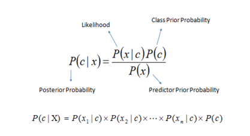

- `posterior:` Probabilty of the current subject c by knowing that word x has appeared in the content.
- `prior:` Probability of subject c
- `likelihood:` Probabilty of seeing the word x knowing that the subject is c
- `evidence:` Probabilty of seeing the word x

##### Q3:

**Bigrams:**  
Ex.:

- در باز است
- باز پرنده ای بسیار زیبا است\

In the above sentences, 'باز' has two diffrent meaning and can make confusion if we use unigram method since we won't know what meaning it has for sure. Therefore we can use Bigrams to match either 'در' or 'پرنده' to the 'در'. if we use longer n-gram, it results in better assumption of the meaning of the words but it can make calculations harder.  
Note: In this project, we use only unigram!

##### Q4:

When we use naive bayes equation to calculate probabilty of words, some of the words that appear in one or more subjects, don't exist on other subject(s). Therefore, the probabilty of that word is equal to zero! $$P(x|c)=0$$ Because of this, even if other words matches greatly to one subject,this subject probabilty equals to zero hence the it multiplies to probabilty of x knowing subject is c that equals to zero!

##### Q5:

Solution to the above problem is by using Additive Smoothing.  
To avoid multiply zero, we give a little probablity to this words and for not corrupting the probabilties, we use this equation instead:

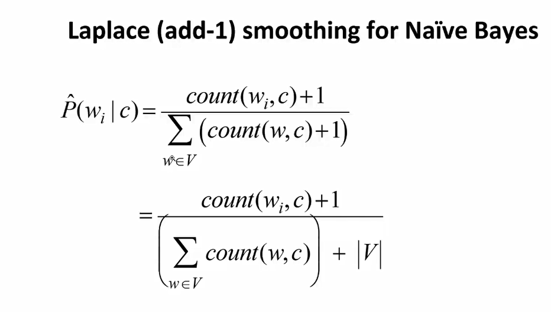

|V|= number of unique words

```python
def evaluation_without_additive_smoothing(test_data_frame):

    𝐶𝑜𝑟𝑟𝑒𝑐𝑡_𝐷𝑒𝑡𝑒𝑐𝑡𝑒𝑑=0
    Detected_Class={'فناوری': 0,'سلامت':0,'سیاسی':0,'ورزشی':0,'حوادث':0,'فرهنگی/هنری':0}
    𝐶𝑜𝑟𝑟𝑒𝑐𝑡_𝐷𝑒𝑡𝑒𝑐𝑡𝑒𝑑_𝐶𝑙𝑎𝑠s={'فناوری': 0,'سلامت':0,'سیاسی':0,'ورزشی':0,'حوادث':0,'فرهنگی/هنری':0}
    Total_Class={'فناوری': 0,'سلامت':0,'سیاسی':0,'ورزشی':0,'حوادث':0,'فرهنگی/هنری':0}

    for index,data in test_data_frame.iterrows():
        chances={'فناوری': 1,'سلامت':1,'سیاسی':1,'ورزشی':1,'حوادث':1,'فرهنگی/هنری':1}
        for word in data.content:
            if word in subjects['حوادث']:
                chances['حوادث'] *= (subjects['حوادث'][word]/train_havades_total_number_of_words)
            else:
                chances['حوادث']=0

            if word in subjects['فناوری']:
                chances['فناوری'] *= (subjects['فناوری'][word]/train_fanavari_total_number_of_words)
            else:
                chances['فناوری']=0

            if word in subjects['سلامت']:
                chances['سلامت'] *= (subjects['سلامت'][word]/train_salamat_total_number_of_words)
            else:
                chances['سلامت']=0

            if word in subjects['سیاسی']:
                chances['سیاسی'] *= (subjects['سیاسی'][word]/train_siasi_total_number_of_words)
            else:
                chances['سیاسی']=0

            if word in subjects['ورزشی']:
                chances['ورزشی'] *= (subjects['ورزشی'][word]/train_varzeshi_total_number_of_words)
            else:
                chances['ورزشی']=0

            if word in subjects['فرهنگی/هنری']:
                chances['فرهنگی/هنری'] *= (subjects['فرهنگی/هنری'][word]/train_farhangi_total_number_of_words)
            else:
                chances['فرهنگی/هنری']=0


        max_chance=max(chances,key=chances.get)
        if(max_chance==data.label):
            Correct_Detected_Class[data.label]+=1
            𝐶𝑜𝑟𝑟𝑒𝑐𝑡_𝐷𝑒𝑡𝑒𝑐𝑡𝑒𝑑+=1
        Detected_Class[max_chance]+=1
        Total_Class[data.label]+=1




    return Correct_Detected,Detected_Class,Correct_Detected_Class,Total_Class
```

##### Q6

##### Plot Words Freuency

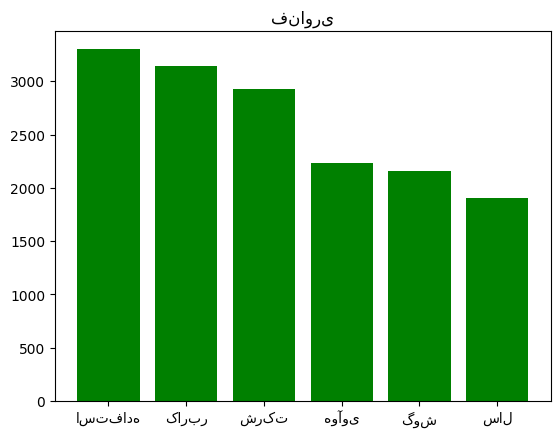

[figure not shown]

[figure not shown]

[figure not shown]

[figure not shown]

[figure not shown]

```python
from bidi.algorithm import get_display
fanavari_sorted=dict(sorted(subjects['فناوری'].items(), key = itemgetter(1), reverse = True)[:6])
bar1 = plt.bar(fanavari_sorted.keys(),fanavari_sorted.values(),color='green')
plt.title('فناوری')
plt.show()

havades_sorted=dict(sorted(subjects['حوادث'].items(), key = itemgetter(1), reverse = True)[:6])
bar2 = plt.bar(havades_sorted.keys(),fanavari_sorted.values(),color='green')
plt.title('حوادث')
plt.show()

siasi_sorted=dict(sorted(subjects['سیاسی'].items(), key = itemgetter(1), reverse = True)[:6])
bar3 = plt.bar(siasi_sorted.keys(),fanavari_sorted.values(),color='green')
plt.title('سیاسی')
plt.show()

varzeshi_sorted=dict(sorted(subjects['ورزشی'].items(), key = itemgetter(1), reverse = True)[:6])
bar4 = plt.bar(varzeshi_sorted.keys(),fanavari_sorted.values(),color='green')
plt.title('ورزشی')
plt.show()

salamat_sorted=dict(sorted(subjects['سلامت'].items(), key = itemgetter(1), reverse = True)[:6])
bar6 = plt.bar(salamat_sorted.keys(),fanavari_sorted.values(),color='green')
plt.title('سلامت')
plt.show()

farhangi_sorted=dict(sorted(subjects['فرهنگی/هنری'].items(), key = itemgetter(1), reverse = True)[:6])
bar6 = plt.bar(farhangi_sorted.keys(),fanavari_sorted.values(),color='green')
plt.title('فرهنگی/هنری')
plt.show()
```

### Faze 3: EVALUATION

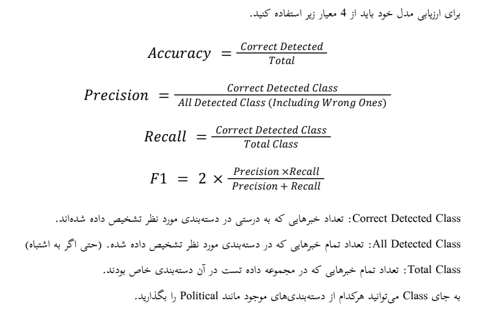

##### Q7

If the code detects a few classes out of a large data-set,for example 5 out of 10000 subjects,then the Percision might be 100% but actualy our code sucks.  
On the other hand, if our code detecs large number of subjects as one particular subject(for example our code predicts all subjects are 'سیاسی'),then Recall might be 100% but our code still sucks.

##### Q8

F1 Score is the harmonic mean of Precision and Recall. Therefore, this score takes both false positives and false negatives into account. Intuitively it is not as easy to understand as accuracy, but F1 is usually more useful than accuracy, especially if you have an uneven class distribution. Accuracy works best if false positives and false negatives have similar cost. If the cost of false positives and false negatives are very different, it’s better to look at both Precision and Recall.

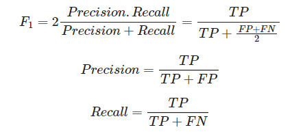

##### Q9

Micro: computes f1 by value total true positives, false negatives and false positives (no matter of the prediction for each label in the dataset)

Macro: computess f1 for each label, and returns the average without considering the proportion for each label in the dataset.

Weighted: computes f1 for each label, and returns the average considering the proportion for each label in the dataset.

```python
test_data_frame = Normalizer('train.csv')

Correct_Detected,Detected_Class,Correct_Detected_Class,Total_Class=evaluation_without_additive_smoothing(test_data_frame)
print(Fore.RED,Correct_Detected,Fore.RESET)
print(Detected_Class)
print(Correct_Detected_Class)
print(Total_Class)
```

```
 4481
{'فناوری': 5898, 'سلامت': 271, 'سیاسی': 658, 'ورزشی': 793, 'حوادث': 902, 'فرهنگی/هنری': 478}
{'فناوری': 1481, 'سلامت': 259, 'سیاسی': 605, 'ورزشی': 786, 'حوادث': 888, 'فرهنگی/هنری': 462}
{'فناوری': 1500, 'سلامت': 1500, 'سیاسی': 1500, 'ورزشی': 1500, 'حوادث': 1500, 'فرهنگی/هنری': 1500}
```

```python
print(Back.BLUE,Fore.BLACK,"RESULTS WITHOUT ADDITIVE SOOTHING:",Fore.RESET,Back.RESET)
print()
print(Back.GREEN,"Accuracy: ",Back.RESET,Fore.RED, Correct_Detected / len(test_data_frame),Fore.RESET)
print()

print("Precision, Recall, and F1:")

for sub in subjects.keys():
    print(Back.RED,sub,Back.RESET)
    precision = Correct_Detected_Class[sub] / Detected_Class[sub]
    recall = Correct_Detected_Class[sub] / Total_Class[sub]
    f1 = (2 * precision * recall) / (precision + recall)

    print("Precision:", precision)
    print("Recall:", recall)
    print("F1:", f1)
    print()
```

```
  RESULTS WITHOUT ADDITIVE SOOTHING:

 Accuracy:    0.4978888888888889

Precision, Recall, and F1:
 فناوری
Precision: 0.25110206849779587
Recall: 0.9873333333333333
F1: 0.40037848067045145

 سلامت
Precision: 0.955719557195572
Recall: 0.17266666666666666
F1: 0.2924901185770751

 سیاسی
Precision: 0.9194528875379939
Recall: 0.4033333333333333
F1: 0.5607043558850787

 ورزشی
Precision: 0.9911727616645649
Recall: 0.524
F1: 0.6855647623201048

 حوادث
Precision: 0.9844789356984479
Recall: 0.592
F1: 0.7393838467943381

 فرهنگی/هنری
Precision: 0.9665271966527197
Recall: 0.308
F1: 0.46713852376137516
```

##### Q10

**Macro Average Without Additive Smoothing:** $$Recall=\frac{0.98+0.17+0.40+0.52+0.59+0.30}{6}=0.49$$ $$Percision=\frac{0.25+0.95+0.91+0.99+0.98+0.96}{6}=0.84$$ $$F1=\frac{0.40+0.29+0.56+0.68+0.73+0.46}{6}=0.52$$

**Weighted Average Without Additive Smoothing:** $$Recall=\frac{1500(0.98+0.17+0.40+0.52+0.59+0.30)}{1500*6}==0.49$$ $$Percision=\frac{1500(0.25+0.95+0.91+0.99+0.98+0.96)}{1500*6}=0.84$$ $$F1=\frac{1500(0.40+0.29+0.56+0.68+0.73+0.46)}{1500*6}=0.52$$

```python
wrong_datas=[]
```

### With Additive Smoothing Test

```python
def evaluation_with_additive_smoothing(test_data_frame):
    𝐶𝑜𝑟𝑟𝑒𝑐𝑡_𝐷𝑒𝑡𝑒𝑐𝑡𝑒𝑑=0
    Detected_Class={'فناوری': 0,'سلامت':0,'سیاسی':0,'ورزشی':0,'حوادث':0,'فرهنگی/هنری':0}
    𝐶𝑜𝑟𝑟𝑒𝑐𝑡_𝐷𝑒𝑡𝑒𝑐𝑡𝑒𝑑_𝐶𝑙𝑎𝑠s={'فناوری': 0,'سلامت':0,'سیاسی':0,'ورزشی':0,'حوادث':0,'فرهنگی/هنری':0}
    Total_Class={'فناوری': 0,'سلامت':0,'سیاسی':0,'ورزشی':0,'حوادث':0,'فرهنگی/هنری':0}

    for index,data in test_data_frame.iterrows():
        chances={'فناوری': 1,'سلامت':1,'سیاسی':1,'ورزشی':1,'حوادث':1,'فرهنگی/هنری':1}
        for word in data.content:
            chances['حوادث'] += ((subjects['حوادث'].get(word,0)+1) / (train_havades_total_number_of_words+train_havades_number_of_unique_words))

            chances['فناوری'] += ((subjects['فناوری'].get(word,0)+1) / (train_fanavari_total_number_of_words+train_fanavari_number_of_unique_words))

            chances['سلامت'] += ((subjects['سلامت'].get(word,0)+1) / (train_salamat_total_number_of_words+train_salamat_number_of_unique_words))

            chances['سیاسی'] += ((subjects['سیاسی'].get(word,0)+1) / (train_siasi_total_number_of_words+train_siasi_number_of_unique_words))

            chances['ورزشی'] += ((subjects['ورزشی'].get(word,0)+1) / (train_varzeshi_total_number_of_words+train_varzeshi_number_of_unique_words))

            chances['فرهنگی/هنری'] += ((subjects['فرهنگی/هنری'].get(word,0)+1) / (train_farhangi_total_number_of_words+train_farhangi_number_of_unique_words))



        max_chance=max(chances,key=chances.get)
        if(max_chance==data.label):
            Correct_Detected_Class[data.label]+=1
            𝐶𝑜𝑟𝑟𝑒𝑐𝑡_𝐷𝑒𝑡𝑒𝑐𝑡𝑒𝑑+=1
        else:
            wrong_datas.append((data.content,data.label,max_chance))
        Detected_Class[max_chance]+=1
        Total_Class[data.label]+=1




    return Correct_Detected,Detected_Class,Correct_Detected_Class,Total_Class
```

```python
Correct_Detected,Detected_Class,Correct_Detected_Class,Total_Class=evaluation_with_additive_smoothing(test_data_frame)
print(Correct_Detected)
print(Detected_Class)
print(Correct_Detected_Class)
print(Total_Class)
```

```
8071
{'فناوری': 1396, 'سلامت': 1470, 'سیاسی': 1671, 'ورزشی': 1587, 'حوادث': 1675, 'فرهنگی/هنری': 1201}
{'فناوری': 1309, 'سلامت': 1361, 'سیاسی': 1325, 'ورزشی': 1470, 'حوادث': 1447, 'فرهنگی/هنری': 1159}
{'فناوری': 1500, 'سلامت': 1500, 'سیاسی': 1500, 'ورزشی': 1500, 'حوادث': 1500, 'فرهنگی/هنری': 1500}
```

```python
print(Back.BLUE,Fore.BLACK,"RESULTS WITH ADDITIVE SOOTHING:",Fore.RESET,Back.RESET)
print()
print(Back.GREEN,"Accuracy: ",Back.RESET,Fore.RED, Correct_Detected / len(test_data_frame),Fore.RESET)
print()

print("Precision, Recall, and F1:")

for sub in subjects.keys():
    print(Back.RED,sub,Back.RESET)
    precision = Correct_Detected_Class[sub] / Detected_Class[sub]
    recall = Correct_Detected_Class[sub] / Total_Class[sub]
    f1 = (2 * precision * recall) / (precision + recall)

    print("Precision:", precision)
    print("Recall:", recall)
    print("F1:", f1)
    print()
```

```
  RESULTS WITH ADDITIVE SOOTHING:

 Accuracy:    0.8967777777777778

Precision, Recall, and F1:
 فناوری
Precision: 0.9376790830945558
Recall: 0.8726666666666667
F1: 0.9040055248618785

 سلامت
Precision: 0.9258503401360544
Recall: 0.9073333333333333
F1: 0.9164983164983165

 سیاسی
Precision: 0.7929383602633154
Recall: 0.8833333333333333
F1: 0.8356985178177231

 ورزشی
Precision: 0.9262759924385633
Recall: 0.98
F1: 0.9523809523809523

 حوادث
Precision: 0.8638805970149254
Recall: 0.9646666666666667
F1: 0.9114960629921259

 فرهنگی/هنری
Precision: 0.9650291423813488
Recall: 0.7726666666666666
F1: 0.8582006664198444
```

##### Q10

**Macro Average With Additive Smoothing:** $$Recall=\frac{0.87+0.90+0.88+0.98+0.96+0.77}{6}=0.89$$ $$Percision=\frac{0.93+0.90+0.79+0.92+0.86+0.96}{6}=0.89$$ $$F1=\frac{0.90+0.91+0.83+0.95+0.91+0.85}{6}=0.89$$

**Weighted Average With Additive Smoothing:** $$Recall=\frac{1500(0.87+0.90+0.88+0.98+0.96+0.77)}{1500*6}=0.89$$ $$Percision=\frac{1500(0.93+0.90+0.79+0.92+0.86+0.96)}{1500*6}=0.89$$ $$F1=\frac{1500(0.90+0.91+0.83+0.95+0.91+0.85)}{1500*6}=0.89$$

### non-additive smoothing

[figure not shown]

### additive smoothing

[figure not shown]

##### Q11

As the results show, There is a significant improvement in the result when Additive Smoothing is used.

##### Q12

```python
for i in range(5):
    print("Original Subject:",wrong_datas[i][1])
    print("Predicted Subject:",wrong_datas[i][2])
    print("Content:",wrong_datas[i][0])
    print()
```

```
Original Subject: سیاسی
Predicted Subject: ورزشی
Content: ['ادوارد', 'اسنودن', 'مأمور', 'سابق', 'آژانس', 'امنیت', 'ملی', 'آمریکا', 'عواقب', 'کار', 'افسوس', 'خورد']

Original Subject: سلامت
Predicted Subject: ورزشی
Content: ['واکسیناسیون', 'سالمند', '۷۰', 'سال', 'فردا', 'شنبه', 'خرداد', 'آغاز', 'سامانه', 'وزارت', 'بهداشت', 'ثبت\u200cنام', 'جهت', 'نوبت\u200cدهی', 'واکسیناسیون', 'اقدام', 'گزارش', 'ایسنا', 'بنابر', 'اعلام', 'کانال', 'تلگرام', 'وزارت', 'بهداشت', 'دکتر', 'علیرضا', 'رییس', 'سخنگو', 'ستاد', 'ملی', 'م…

Original Subject: سلامت
Predicted Subject: ورزشی
Content: ['قصد', 'ورزش', 'نتیجه', 'واقعی', 'ورزش', 'عادت', 'دست', 'بیگاه', 'ورزش', 'تاثیر', 'واقعی', 'مشاهده', 'گزارش', '\u200cایسنا', 'ورزش', 'موثر', 'روز', 'هفته', 'انجام', 'جلسه', 'وزنه', 'زدن', 'پایان', 'ورزش', 'قلب', '–', 'عروق', 'هفته', 'ورزش', 'استقامت', 'هفته', 'انجام', 'نتایج', 'میزان', 'ور…

Original Subject: فرهنگی/هنری
Predicted Subject: حوادث
Content: ['رامبد', 'جوان', 'پیام', 'تبریک', 'واسطه', 'تولد', 'فرزند', 'دریافت', 'تشکر', 'گزارش', 'ایلنا', 'سرانجام', 'حواشی', 'سفر', 'رامبد', 'جوان', 'نگار', 'جواهر', 'کانادا', 'همراه', 'دختر', 'بازیگر', 'دنیا', 'رامبد', 'جوان', 'تازه', 'پست', 'اینستاگرامی', 'پیام', 'تبریک', 'طرفدار', 'مخاطبانش', 'ق…

Original Subject: حوادث
Predicted Subject: سیاسی
Content: ['فرماندار', 'شهرستان', 'کلات', 'کشته', 'جوان', 'کلات', 'توسط', 'مرزبان', 'ترکمنستان', 'خبر', 'گزارش', 'ایلنا', 'کلات', 'مهدی', 'ناصر', 'این\u200cباره', 'مرزبان', 'کشور', 'ترکمنستان', 'اعلام', 'تجاوز', 'مرز', 'صورت', 'جوان', 'به\u200cفرمان', 'ایست', 'توجه', 'فرماندار', 'کلات', 'توجه', 'توجه…
```

As we can see, words are in both subjects and that can be difficult to know witch subject it is belong to. With more number and more advanced train data, we can increase efficiency of the code.